# 2 Way ANOVA Recipe

Rhys Maredudd Davies

2024-02-22

## The Problem

The Humans and Martians living together at Mars colony of Marset1. Recently, a population of advanced **Androids** have joined them. All of these groups have bonded and shared their love of the arts and entertainment. However, a beloved Movie franchise about an inter-galactic fight for justice and freedom ( **“Star-Battle”**) has sparked debate amongst it’s loyal fans.

The loyal fans amongst the Humans, Martians and Androids are all claiming that their population group enjoyed **Star-Battle** the most. Yet, across the non-fans, there appears to be diversity in opinion linked to diversity of representation within the franchise.

It has been noted that the key heroes of the series have been assigned to the **human** characters. Meanwhile, the **martians** tend to be portrayed as supporting characters (although some have central roles to the plot). Lastly, it is noted that the **androids** in the series are resigned to minor roles, with some taking great offence to not being *“the droids you are looking for…”*.

As an external researcher, you have been assigned with investigating the debate started by the loyal **Star-Battle** fans. They want to know which population base enjoyed the series the most, when accounting for fans/non-fans.

## Measures

The data collected contains information on `Franchise_enjoyment`, `population_group`, and `fan-status`.

The `Franchise_enjoyment` measure is a `0-100` scale. With `0` representing *no enjoyment at all*, and `100` representing a fanatical, 100% adoration for the series.

The `population_group` measure is a categorical/nominal measure, representing the 3 population groups: `human`, `martian`, and `android`.

The `fan-status` measure is a binary categorical/nominal measure, representing 2 sub-population groups: `loyal_fan` and `non_fan`.

## The research question

Which group has the biggest fans of the Star-Battle franchise, when accounting for whether each individual identifies as a `loyal_fan` or `non_fan`?

- Hypothesis 1) Those identifying as a `loyal_fan` will have larger approval scores of the Star-Battle franchise than those identifying as `non_fan`.
- Hypothesis 2a) Both `human` and `martian` population groups will have higher approval scores of the Star-Battle franchise in comparison to the `android` population group.
- Hypothesis 2b) The `human` group will have a higher approval in comparison to the `martian` group.
- Hypothesis 3a) The `loyal_fan` group within the `human` group will have the **highest** overall enjoyment.
- Hypothesis 3b) The `non_fan` group within the `android` group will have the **lowest** overall enjoyment.

## The analysis

To analyse this question, we need to compare the scores of the *numerical* `Franchise_enjoyment` outcome variable between **both** the `population_group` and `fan_status` *nominal* predictor variables. Ultimately, we are also investigating if there is an **interaction/moderator** effect between the predictor variables in determining `Franchise_enjoyment`.

To do this, we will be using the **2-way ANOVA**.

### Demographics and Descriptive statistics

First off, we need to understand our data. We can do this through checking our data through the `summary()` function, and through some data wrangling with the `group_by()` and `summarise()` functions.

```r
summary(Star_battle)
```

```
##  population_group     fan_status  Franchise_enjoyment
##  android: 60      loyal_fan:119   Min.   : 9.00
##  human  :100      non_fan  :121   1st Qu.:41.75
##  martian: 80                      Median :50.00
##                                   Mean   :52.03
##                                   3rd Qu.:65.25
##                                   Max.   :90.00
```

```r
table <- Star_battle %>%
  group_by(population_group,
           fan_status) %>%
  summarise( n = n(),
            mean_enjoy = round(mean(Franchise_enjoyment),2),
            sd_enjoy = round(sd(Franchise_enjoyment),2)
  )
table
```

```
## # A tibble: 6 × 5
## # Groups:   population_group [3]
##   population_group fan_status     n mean_enjoy sd_enjoy
##   <fct>            <fct>      <int>      <dbl>    <dbl>
## 1 android          loyal_fan     30       50.3     7.03
## 2 android          non_fan       30       19.6     5.6
## 3 human            loyal_fan     50       78.7     4.47
## 4 human            non_fan       50       49.5     5.08
## 5 martian          loyal_fan     39       61.1     8.81
## 6 martian          non_fan       41       38.8     6.79
```

### Data distribution

Now that we have an understanding of our summary statistics, it’s time to inspect the distribution of our data through the use of histograms. Thankfully, ggplot makes it very simple to test across the different groups through the use of `facet_wrap()` and `fill = ...` commands.

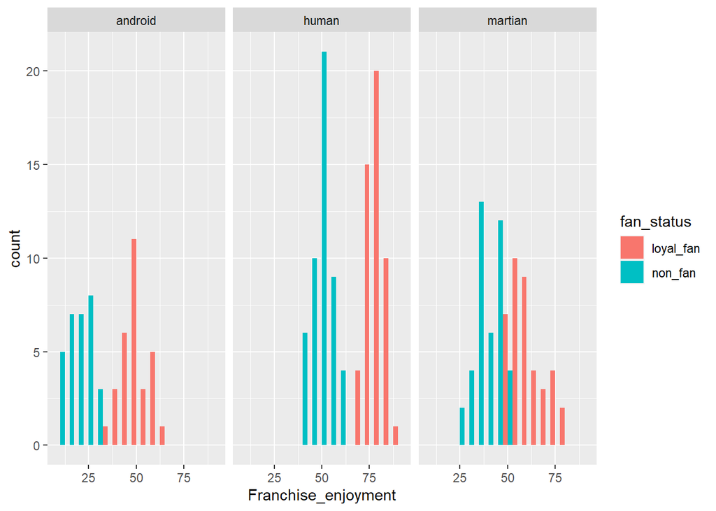

```r
ggplot(Star_battle,
       aes(x = Franchise_enjoyment, fill = fan_status )) +
  geom_histogram(binwidth =5, position = "dodge") +
  facet_wrap(~population_group)
```

As we can see, the data approximates normal across our `population_group` and `fan_status` variables.

## 1 way ANOVA (on each nominal variable)

### Fan status

```r
m <- aov(Franchise_enjoyment ~ fan_status, data = Star_battle)

summary(m)
```

```
##              Df Sum Sq Mean Sq F value Pr(>F)
## fan_status    1  44640   44640   249.2 <2e-16 ***
## Residuals   238  42629     179
## ---
## Signif. codes:  0 '***' 0.001 '**' 0.01 '*' 0.05 '.' 0.1 ' ' 1
```

```r
DescTools::PostHocTest(m, method = "bonferroni")
```

```
##
##   Posthoc multiple comparisons of means : Bonferroni
##     95% family-wise confidence level
##
## $fan_status
##                        diff    lwr.ci    upr.ci   pval
## non_fan-loyal_fan -27.27738 -30.68118 -23.87358 <2e-16 ***
##
## ---
## Signif. codes:  0 '***' 0.001 '**' 0.01 '*' 0.05 '.' 0.1 ' ' 1
```

### T-test (equivalent)

Those with keen eyes will notice that we have ran an ANOVA on a **binary** categorical variable! (The horror!!). But fun/nerdy stats fact: the *t-test* is in the same family as ANOVA. It has the same underlying assumptions and behind the scenes maths. The only difference is that *t-test* is a special form that only works on **binary** variables. Meanwhile, the ANOVA is less fussy about the number of groups it takes on. 3+ is always a party for ANOVA.

Anyhow, for peace of mind, let’s have a look at the *t-test* results below, and see how they compare to the ANOVA results above.

```r
t.test(Franchise_enjoyment ~ fan_status, data = Star_battle)
```

```
##
##  Welch Two Sample t-test
##
## data:  Franchise_enjoyment by fan_status
## t = 15.783, df = 237.42, p-value < 2.2e-16
## alternative hypothesis: true difference in means between group loyal_fan and group non_fan is not equal to 0
## 95 percent confidence interval:
##  23.87261 30.68215
## sample estimates:
## mean in group loyal_fan   mean in group non_fan
##                65.78151                38.50413
```

```r
Star_battle %>%
  group_by(fan_status) %>%
  summarise( n = n(),
            mean_enjoy = round(mean(Franchise_enjoyment),2),
            sd_enjoy = round(sd(Franchise_enjoyment),2)
  )
```

```
## # A tibble: 2 × 4
##   fan_status     n mean_enjoy sd_enjoy
##   <fct>      <int>      <dbl>    <dbl>
## 1 loyal_fan    119       65.8     13.6
## 2 non_fan      121       38.5     13.2
```

(Clue: look at the CI/Confidence intervals for both analyses, and compare the `diff` score to the differences in `mean` group values…).

Statistical trivia aside, what are the results?

Well it appears that as expected, the `loyal_fan` group (*M* = 65.78, *sd* = 13.6 ) do have a higher `Franchise_enjoyment` score (*t*(237.4) = 15.78, *p* < .001) in comparison to the `non-fan` group (*M* = 38.50, *sd* = 13.16).

### Population group ANOVA

What about our population groups? Let’s check our ANOVA to inspect.

```r
m <- aov(Franchise_enjoyment ~ population_group , data = Star_battle)

summary(m)
```

```
##                   Df Sum Sq Mean Sq F value Pr(>F)
## population_group   2  32603   16302   70.67 <2e-16 ***
## Residuals        237  54666     231
## ---
## Signif. codes:  0 '***' 0.001 '**' 0.01 '*' 0.05 '.' 0.1 ' ' 1
```

Again, it appears there is a significant difference in population groups in determining `Franchise_enjoyment` of the `Star_battle` series (*F*(2,237) = 70.67, *p* <.001).

This is great to know, but to go one step further we need to run a post-hoc analysis to examine the differences between each group by pairs (i.e., `human` vs `martian`, `martian` vs `android`, `android` vs `human`). This is done through a series of t-tests with a [**bonferroni**](https://en.wikipedia.org/wiki/Bonferroni_correction) *p value* adjustment applied.

Note: P-value adjustments are used to minimise our risk of gaining a **False Positive** result. This makes them very important for reducing the risk of our analyses accidentally misinforming any decisions/implications.

```r
DescTools::PostHocTest(m, method = "bonferroni")
```

```
##
##   Posthoc multiple comparisons of means : Bonferroni
##     95% family-wise confidence level
##
## $population_group
##                   diff     lwr.ci    upr.ci    pval
## human-android    29.19  23.210269 35.169731 < 2e-16 ***
## martian-android  14.75   8.496247 21.003753 1.1e-07 ***
## martian-human   -14.44 -19.932734 -8.947266 3.5e-09 ***
##
## ---
## Signif. codes:  0 '***' 0.001 '**' 0.01 '*' 0.05 '.' 0.1 ' ' 1
```

```r
Star_battle %>%
  group_by(population_group) %>%
  summarise( n = n(),
            mean_enjoy = round(mean(Franchise_enjoyment),2),
            sd_enjoy = round(sd(Franchise_enjoyment),2)
  )
```

```
## # A tibble: 3 × 4
##   population_group     n mean_enjoy sd_enjoy
##   <fct>            <int>      <dbl>    <dbl>
## 1 android             60       35.0     16.7
## 2 human              100       64.1     15.4
## 3 martian             80       49.7     13.6
```

So what does our analysis tell us? Firstly, `human` groups (*M* = 64.14, *sd* = 15.43) have a significantly higher levels of `Franchise_enjoyment` (*t* = 29.19, *p*< .001) in comparison to android group (*M* = 34.95, *sd* = 16.68). The humans also have significantly higher levels of `Franchise_enjoyment` (*t* = 14.44, *p*< .001) in comparison to the `martian` group (*M* = 49.70 , *sd* = 13.64).

Finally, the `martian` group also has a significantly levels of `Franchise_enjoyment` (*t* = 14.75, *p*< .001) in comparison to the `android` group (*M* = 34.95, *sd* = 16.68).

### 2 Way Anova

We have now established that `fan_status` and `population_group` are independently significant predictors of `Franchise_enjoyment`. But does this still hold true when the analysis accounts for both variables together? And furthermore, is there a potential interaction?

To test this, we will use the **2 way Anova**.

```r
m <- aov(Franchise_enjoyment ~ population_group * fan_status, data = Star_battle)

summary(m)
```

```
##                              Df Sum Sq Mean Sq  F value   Pr(>F)
## population_group              2  32603   16302  406.688  < 2e-16 ***
## fan_status                    1  44519   44519 1110.662  < 2e-16 ***
## population_group:fan_status   2    767     383    9.563 0.000102 ***
## Residuals                   234   9380      40
## ---
## Signif. codes:  0 '***' 0.001 '**' 0.01 '*' 0.05 '.' 0.1 ' ' 1
```

Here we see that both `population_group` (*F*(2,234)= 406.69, *p* <.001) and `fan_status` (*F*(1,234)= 1110.66, *p* <.001) are significant predictors of the **Star Battle** `Franchise_enjoyment` scores. Beyond this, we see that the *interaction* between `population_group` and `fan_status` is significant (*F*(2,234)= 9.56, *p* <.001).

### Post-hoc tests

To interpret what this all means, it’s time to run our Post-hoc tests again!

```r
DescTools::PostHocTest(m, method = "bonferroni")
```

```
##
##   Posthoc multiple comparisons of means : Bonferroni
##     95% family-wise confidence level
##
## $population_group
##                   diff    lwr.ci    upr.ci   pval
## human-android    29.19  26.69700  31.68300 <2e-16 ***
## martian-android  14.75  12.14276  17.35724 <2e-16 ***
## martian-human   -14.44 -16.72997 -12.15003 <2e-16 ***
##
## $fan_status
##                        diff    lwr.ci   upr.ci   pval
## non_fan-loyal_fan -27.23856 -28.84892 -25.6282 <2e-16 ***
##
## $`population_group:fan_status`
##                                            diff     lwr.ci     upr.ci    pval
## human:loyal_fan-android:loyal_fan    28.4733333  24.137209  32.809458 < 2e-16
## martian:loyal_fan-android:loyal_fan  10.8358974   6.276222  15.395573 3.0e-10
## android:non_fan-android:loyal_fan   -30.6333333 -35.481268 -25.785399 < 2e-16
## human:non_fan-android:loyal_fan      -0.7266667  -5.062791   3.609458  1.0000
## martian:non_fan-android:loyal_fan   -11.4130081 -15.924072  -6.901944 1.9e-11
## martian:loyal_fan-human:loyal_fan   -17.6374359 -21.648689 -13.626183 < 2e-16
## android:non_fan-human:loyal_fan     -59.1066667 -63.442791 -54.770542 < 2e-16
## human:non_fan-human:loyal_fan       -29.2000000 -32.955194 -25.444806 < 2e-16
## martian:non_fan-human:loyal_fan     -39.8863415 -43.842249 -35.930434 < 2e-16
## android:non_fan-martian:loyal_fan   -41.4692308 -46.028907 -36.909555 < 2e-16
## human:non_fan-martian:loyal_fan     -11.5625641 -15.573817  -7.551311 2.5e-14
## martian:non_fan-martian:loyal_fan   -22.2489056 -26.448652 -18.049159 < 2e-16
## human:non_fan-android:non_fan        29.9066667  25.570542  34.242791 < 2e-16
## martian:non_fan-android:non_fan      19.2203252  14.709261  23.731389 < 2e-16
## martian:non_fan-human:non_fan       -10.6863415 -14.642249  -6.730434 8.0e-13
##
## human:loyal_fan-android:loyal_fan   ***
## martian:loyal_fan-android:loyal_fan ***
## android:non_fan-android:loyal_fan   ***
## human:non_fan-android:loyal_fan
## martian:non_fan-android:loyal_fan   ***
## martian:loyal_fan-human:loyal_fan   ***
## android:non_fan-human:loyal_fan     ***
## human:non_fan-human:loyal_fan       ***
## martian:non_fan-human:loyal_fan     ***
## android:non_fan-martian:loyal_fan   ***
## human:non_fan-martian:loyal_fan     ***
## martian:non_fan-martian:loyal_fan   ***
## human:non_fan-android:non_fan       ***
## martian:non_fan-android:non_fan     ***
## martian:non_fan-human:non_fan       ***
##
## ---
## Signif. codes:  0 '***' 0.001 '**' 0.01 '*' 0.05 '.' 0.1 ' ' 1
```

```r
table
```

```
## # A tibble: 6 × 5
## # Groups:   population_group [3]
##   population_group fan_status     n mean_enjoy sd_enjoy
##   <fct>            <fct>      <int>      <dbl>    <dbl>
## 1 android          loyal_fan     30       50.3     7.03
## 2 android          non_fan       30       19.6     5.6
## 3 human            loyal_fan     50       78.7     4.47
## 4 human            non_fan       50       49.5     5.08
## 5 martian          loyal_fan     39       61.1     8.81
## 6 martian          non_fan       41       38.8     6.79
```

Now as you can see, post-hoc tests on 2 way ANOVA’s get rather intense! We have **15** separate comparisons to account for. Of which, **14** are significant (even with the conservative *bonferroni* correction applied). Across these **14** significant comparisons, we see that `loyal_fan` groups have significantly higher `Franchise_enjoyment` scores than the `non-fan` group, regardless of `population_group`… That is, except for the `loyal_fan` `android` group (*M* = 50.27, *sd* = 7.03) in comparison to the `non_fan` `human` group(*M* = 49.54, *sd* = 5.08). There is no significant difference between these 2 particular groups (*t* = -0.72, *p* = 1.00).

## Plotting the results

Now, reading that wall of numbers for the post-hoc 2 Way ANOVA was rather intimidating. To make it all easier to interpret, we’re going to visually communicate our results with our boxplot below.

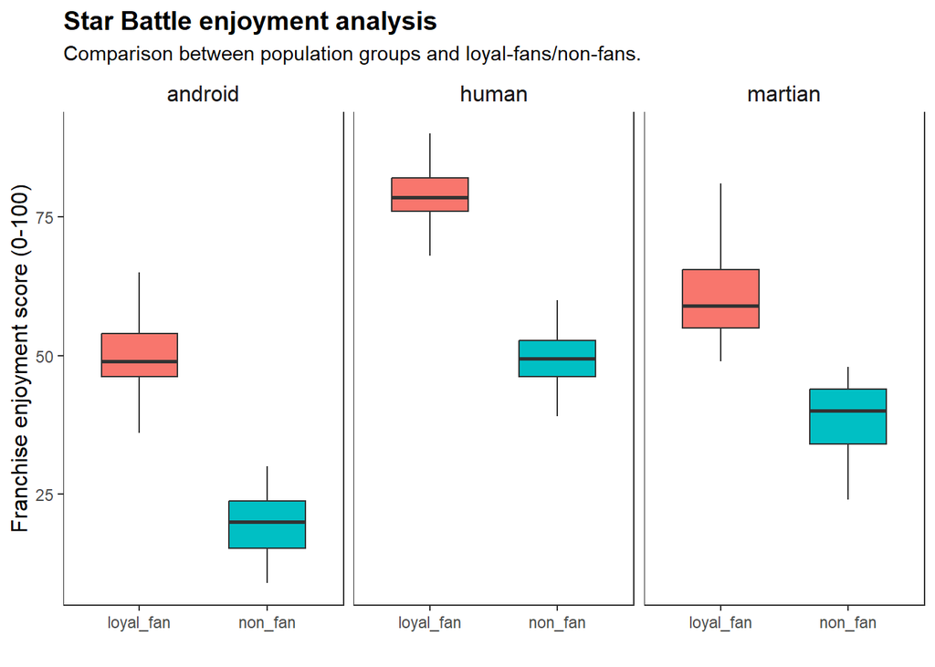

## Conclusion

And there we have it, our recipe for the 2 way ANOVA. Following the analysis, we were able to report back to the residents of the Marset1 colony that the loyal fans will almost always enjoy the Star-Battle franchise more than the non-fans, regardless of the population group (except of loyal fans of the android community, as there was no discernible difference between them and the non-fans of the human community).

In response to the analysis, the producers of the `Star Battle` franchise decided to include more martians and more androids, in more meaningful roles for their future blockbuster - **Star-Battle: Revenge of the Priors**. Their goal is to ensure that even more of the Marset1 colony will enjoy their film.